# Senzorický panel ako merací prístroj

Blok 4 · cvičenia 15 – 16

Senzometria v R · SaIT

## Panel musíme kalibrovať

Pri deskriptívnom profile nahrádza panel laboratórny prístroj. Musí spĺňať tri podmienky naraz:

| pilier | otázka | ANOVA efekt |
| --- | --- | --- |
| **rozlišovanie** | odlišuje produkty? | Product – chceme malé p |
| **zhoda** | hodnotí ako ostatní? | Product:Panelist – chceme veľké p |
| **opakovateľnosť** | rovnako pri opakovaní? | Session, reziduum – malý rozptyl |

Dataset `sensochoc`: 29 hodnotiteľov, 6 čokolád, 2 opakovania, 14 deskriptorov.

## Výkonnosť celého panelu

```r
vykon <- panelperf(sensochoc, firstvar = 5,
  formul = "~Product+Panelist+Session+Product:Panelist+Product:Session+Panelist:Session")
round(vykon$p.value[c("CocoaA", "Bitterness", "Caramel", "Granular"), 1:4], 3)
```

```
           Product          Panelist         Session          Product:Panelist
CocoaA                    0                0            0.239            0.993
Bitterness                0                0            0.012            0.026
Caramel                   0                0            0.949            0.003
Granular                  0                0            0.147            0.015
```

CocoaA: ideálny deskriptor. Caramel, Granular: hodnotitelia sa nezhodujú v poradí produktov. Bitterness: posun medzi opakovaniami.

## Ktoré deskriptory panel rozlišuje najlepšie?

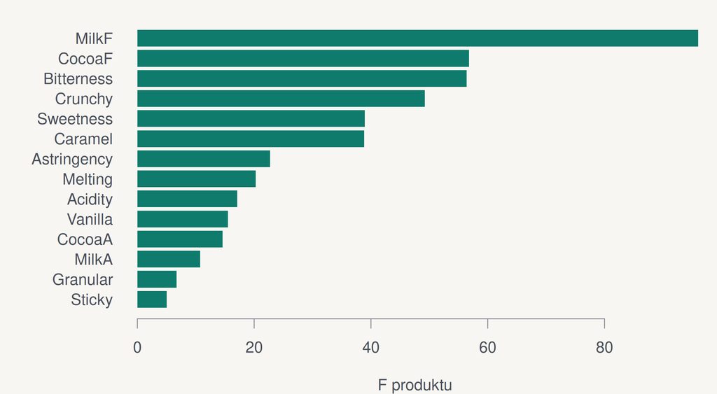

```r
F_prod <- sapply(names(sensochoc)[5:18], function(v) {
  a <- summary(aov(reformulate(
    c("Product", "Panelist", "Session"), v),
    data = sensochoc))[[1]]
  a[1, "F value"]
})
par(mar = c(4, 7, 1, 1))
barplot(sort(F_prod), horiz = TRUE, las = 1,
        col = pal[1], border = NA,
        xlab = "F produktu")
```

Čím vyššie F, tým lepšie panel produkty odlišuje. Graficky to isté ukáže `coltable()` zo SensoMineR (farebná tabuľka p-hodnôt).

## Zhoda a opakovateľnosť hodnotiteľov

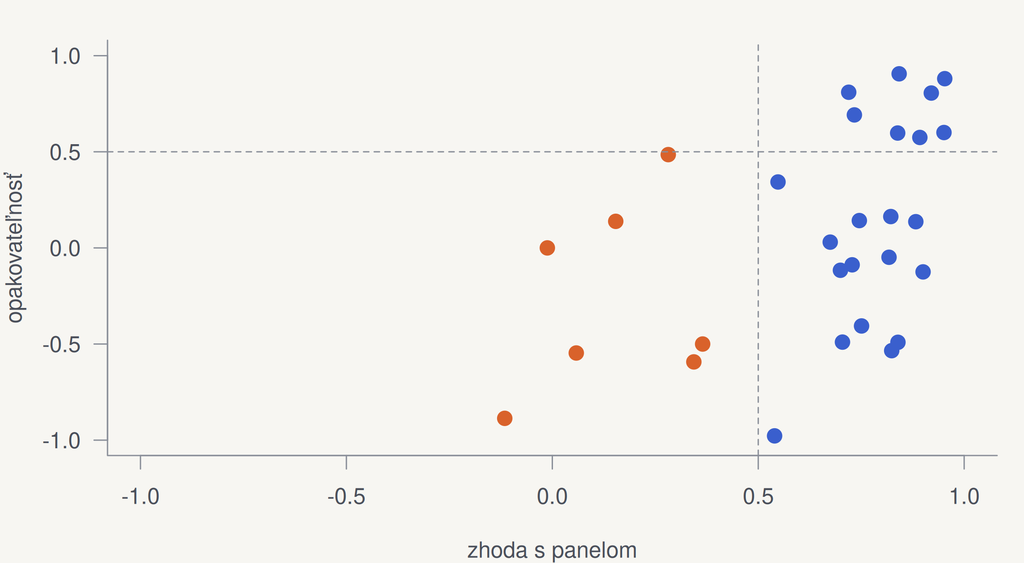

```r
prum <- with(sensochoc, tapply(CocoaA, list(Product, Panelist), mean))
zhoda <- apply(prum, 2, cor, y = rowMeans(prum))
s1 <- with(subset(sensochoc, Session == 1),
           tapply(CocoaA, list(Product, Panelist), mean))
s2 <- with(subset(sensochoc, Session == 2),
           tapply(CocoaA, list(Product, Panelist), mean))
opak <- sapply(colnames(s1), function(h) cor(s1[, h], s2[, h]))
slabi <- zhoda < 0.5 & opak < 0.5
plot(zhoda, opak, pch = 19, cex = 1.4,
     col = ifelse(slabi, pal[2], pal[3]),
     xlim = c(-1, 1), ylim = c(-1, 1),
     xlab = "zhoda s panelom", ylab = "opakovateľnosť")
abline(h = 0.5, v = 0.5, lty = 2)
```

Oranžoví hodnotitelia (7) sú pod hranicou v oboch ukazovateľoch – kandidáti na dotréning.

## KVÍZ Čo s hodnotiteľom?

Hodnotiteľ má vysokú **opakovateľnosť**, ale nízku **zhodu** s panelom. Čo to znamená?

Hodnotí stabilne, ale „po svojom“ – pravdepodobne inak chápe deskriptor. Riešenie: **kalibrácia na referenčné štandardy**, nie vyradenie.

## Pevné vs. náhodné efekty

|  | pevný | náhodný |
| --- | --- | --- |
| úrovne | vybrané zámerne | náhodný výber z populácie |
| príklad | **produkt** | **hodnotiteľ**, šarža, deň |
| zápis v `lmer` | `Product` | `(1 \| Panelist)` |

Záver „A je lepší ako B“ chceme pre **každý** podobný panel, nie len pre našich 29 ľudí → produkt sa testuje voči **nezhode hodnotiteľov** (interakcii).

## Pevný model vs. zmiešaný model

```r
tab <- summary(aov(Bitterness ~ Product * Panelist, data = sensochoc))[[1]]
rownames(tab) <- trimws(rownames(tab))
c(F_pevny = tab["Product", "F value"],
  F_voci_interakcii = tab["Product", "Mean Sq"] / tab["Product:Panelist", "Mean Sq"])
```

```
          F_pevny F_voci_interakcii
         59.87646          49.87641
```

```r
m <- lmer(Bitterness ~ Product + Session + (1 | Panelist) + (1 | Panelist:Product), data = sensochoc)
anova(m)
```

```
Type III Analysis of Variance Table with Satterthwaite's method
        Sum Sq Mean Sq NumDF DenDF F value    Pr(>F)
Product 783.92 156.784     5   140  49.876 < 2.2e-16 ***
Session  31.68  31.681     1   173  10.078  0.001776 **
---
Signif. codes:  0 '***' 0.001 '**' 0.01 '*' 0.05 '.' 0.1 ' ' 1
```

## Rozklad rozptylu

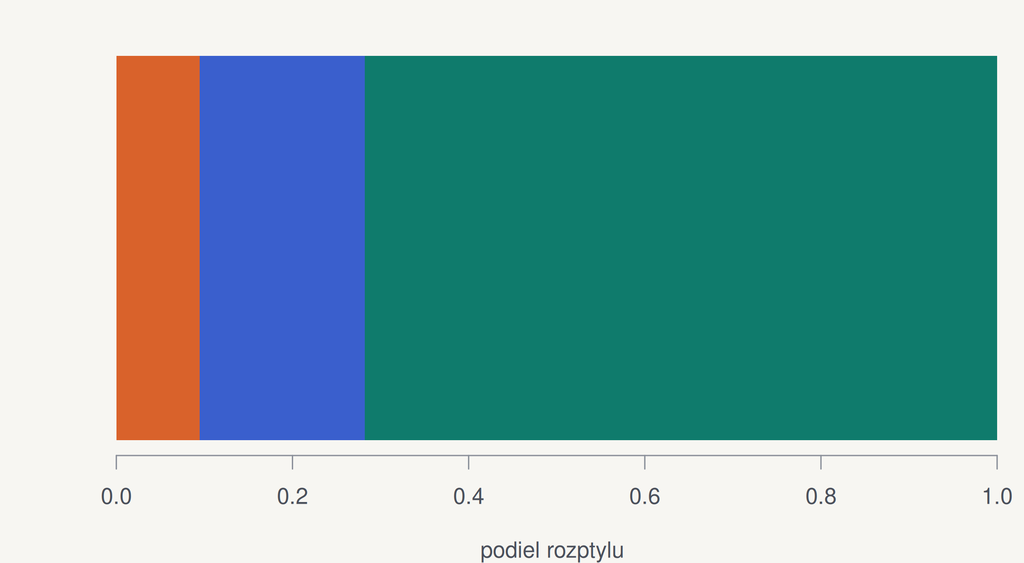

```r
vc <- as.data.frame(VarCorr(m))
podiel <- setNames(vc$vcov / sum(vc$vcov),
                   c("interakcia", "hodnotiteľ", "reziduum"))
barplot(as.matrix(podiel), horiz = TRUE,
        col = pal[c(2, 3, 1)], border = NA,
        xlab = "podiel rozptylu")
```

```r
round(podiel, 2)
```

```
interakcia hodnotiteľ   reziduum
      0.09       0.19       0.72
```

Veľká **interakcia** = zlá zhoda. Veľké **reziduum** = zlá opakovateľnosť. Most medzi výkonnosťou panelu a modelom.

## Post-hoc v zmiešanom modeli

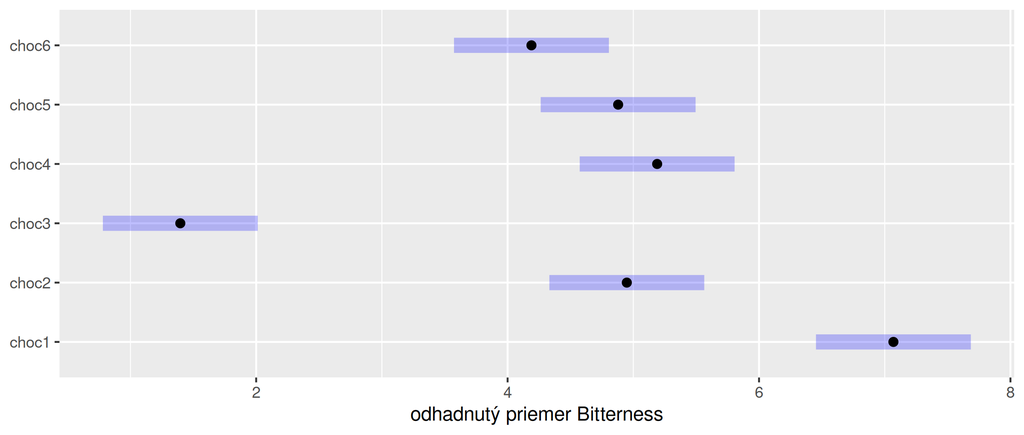

```r
por <- emmeans(m, pairwise ~ Product, adjust = "tukey")
plot(por$emmeans) + ggplot2::labs(x = "odhadnutý priemer Bitterness", y = NULL)
```

## KVÍZ Singular fit

Pri CocoaA vypíše `lmer` varovanie **„boundary (singular) fit“**. Čo sa stalo?

Rozptyl interakcie hodnotiteľ × produkt je odhadnutý na **0** (p interakcie = 0,99) – hodnotitelia sa v CocoaA zhodujú. Model je použiteľný, efekt možno vynechať.

## Zhrnutie

- Panel kontrolujeme pravidelne: **rozlišovanie, zhoda, opakovateľnosť**.
- Slabý hodnotiteľ → najprv **kalibrácia**, vyradenie až nakoniec.
- Hodnotiteľ je **náhodný efekt** → `lmer(y ~ Product + (1 | Panelist) + (1 | Panelist:Product))`.
- Post-hoc cez `emmeans`, nie `TukeyHSD`.

Teória 15 Teória 16